# PML_Assignment

Faisal Mahdi

September 25, 2015

# Synopsis

In this assignment we aimed to fit a predictive model onto a sample set of data (train it) which was captured by ‘Groupware@LES’. That data and associated information can be found [here](http://groupware.les.inf.puc-rio.br/har#weight_lifting_exercises). We used the {caret} package to build our models as well as preprocess and cross-validate them.

After splitting our data into two sets (train and test), we were able to select a good model for predicting the class of activity performed. With an out of sample error rate of 0.49.

## General Strategy

Our general strategy was a list of steps:

- In the first section (code not show) we load our data, clean it a little and get acquainted with it too.
- In the second section we do some data cleansing, we remove some unnecessary columns, as well as clean all NAs. (We do not use imputing)
- In the third and fourth (code not shown)sections we do a lot of exploratory analysis, only a few graphs are shown. In some cases we can clearly see a distinction when it comes to the type of activity performed. That is shown by the distinct colors.
- In the fifth section, we conduct our data processing - more details below.
- In the final section, we perform a few model fits and evaluation. Then based on that we decide which one to choose.

## Data cleansing

Now that the data is downloaded from our source links and loaded into data frames, we do a little cleansing.

```r
# Clean training DF by excluding new_window == yes rows then clean all NA columns
mytraindf <- mytraindf[mytraindf$new_window == "no",]
temp_data <- temp_data[temp_data$new_window == "no",]
temp_data <- cbind(data.frame(X = seq(1:nrow(temp_data))),temp_data)

# Now match the training columns to the test columns
mytraindf <- mytraindf[,colSums(is.na(mytestdf)) != nrow(mytestdf)]
temp_data <- temp_data[,colSums(is.na(mytestdf)) != nrow(mytestdf)]
# Now Clean NA columns in mytestdf
mytestdf <- mytestdf[,colSums(is.na(mytestdf)) != nrow(mytestdf) ]

# Break the predictors down to each device reading
names_forearm <- names(mytraindf[,c(which(grepl("forearm",names(mytraindf))),60)])
names_arm <- names(mytraindf[,c(which(grepl("_arm",names(mytraindf))),60)])
names_belt <- names(mytraindf[,c(which(grepl("_belt",names(mytraindf))),60)])
names_dumbbell <- names(mytraindf[,c(which(grepl("dumbbell",names(mytraindf))),60)])
```

## Data exploration

We drew many plots, playing around with many possibilites of both the predictors as well as filtering per user, or even per class. However, we only chose a few examples for display. Ones where clustering of a certain colour can be more visible.

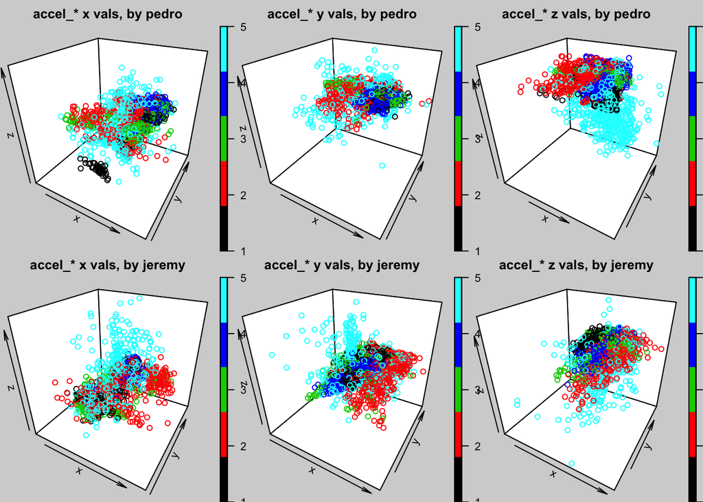

#### Let us view the effects of other predictors

Here we plot against “magnet_*" predictors.

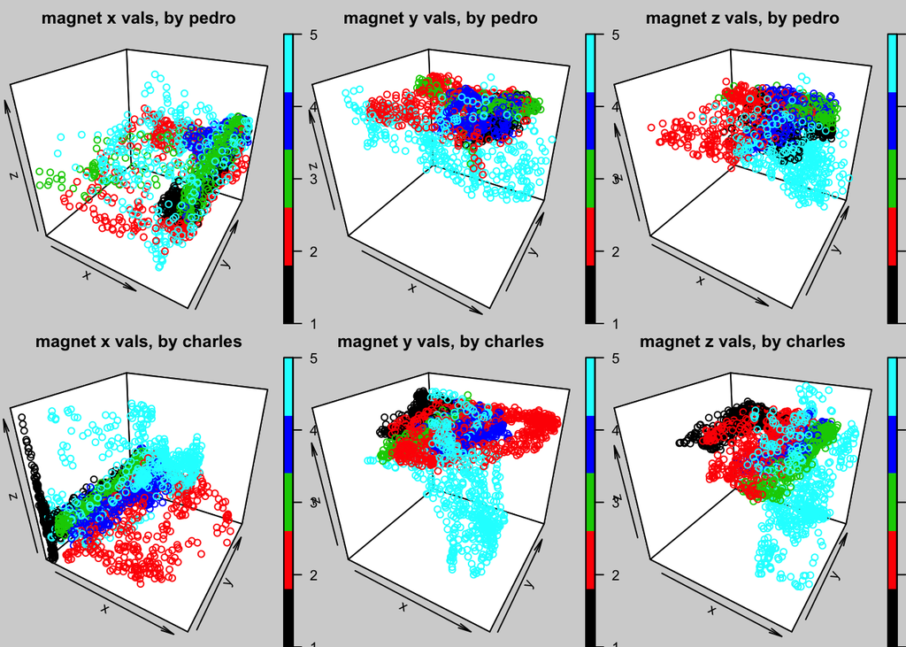

## Preprocessing

Based on our exploration, we removed further variables which we did not find as relevant. That stage made decissions in this stage a little easier. However, we still had to make a few more tasks: - Select the predictors we found to be more relevant (accel_, magnet, user, classe etc ) - Transform both our training , and test sets alike. - Break our training set further into training_set 80% of our original training set, and 20% to our new test set. - Find any correlations and for those above 90% , remove them. - Conduct a Principle component analysis operation to build new predictors from the old ones. Note in this step we maintaned our original training sets for comparison. - Perform the same transformation on all sets as we did on the training_set

```r
library(caret)

# Set seed for reproducibility
set.seed(1)

# remove 1,7 , and some others based upon our exploration
possible_columns <- names(mytraindf[grepl("accel|magnet|gyros_.*_z|user|classe",names(mytraindf))])
final_train <- mytraindf[,possible_columns]
final_test_pb <- mytestdf[,c(possible_columns[1:33],"problem_id")]
# final_temp <- temp_data[,possible_columns[1:34],]


# also do some findCorrelation
temp <- findCorrelation(cor(final_train[,-c(1,34)]))
# See what we got
names(final_train[,c(temp+1)])
```

```
## [1] "accel_belt_z"    "accel_belt_y"    "gyros_forearm_z"
```

```r
# It looks good so we will remove them
final_train <- final_train[,-c(temp+1)]
final_test_pb <- final_test_pb[,-c(temp+1)]
# final_temp <- final_temp[,-c(temp+1)]
# Now we split the data into train/test sets
inTrain <- createDataPartition(final_train$classe,p=0.8,list=F)
training_set <- final_train[inTrain,]
testing_set <- final_train[-inTrain,]

# run PCA on all but the factors
final_pca_PP <- preProcess(training_set[,-c(1,31)],method="pca")

# Now that we have our PCA conversion, we apply it to all our training and test sets, then add our
final_tr_pca <- predict(final_pca_PP,training_set[,-c(1,31)])
final_tr_pca <- cbind(final_tr_pca,training_set[,c(1,31)])
final_ts_pca <- predict(final_pca_PP,testing_set[,-c(1,31)])
final_ts_pca <- cbind(final_ts_pca,testing_set[,c(1,31)])
# These are the actual problem files
final_ts_pca_pb <- predict(final_pca_PP,final_test_pb[,-c(1,31)])
final_ts_pca_pb <- cbind(final_ts_pca_pb,final_test_pb[,c(1,31)])
```

## Model Fitting

In this section we performed several train() operations as well as choosing our 10 k-fold Cross-validation operation. Details can be seen in the code below.

```r
library(caret)
# Let us use Cross Validation K-fold = 10
tr_ctrl <- trainControl(method = "repeatedcv", number = 10)

# Let us use boosting on our PCAs
if (!"model_gbm_pca" %in% ls()) {
    model_gbm_pca <- train(classe ~ . , trControl = tr_ctrl, method ="gbm",data = final_tr_pca, verbose=F)
}
mypred_gbm_pca <- predict(model_gbm_pca,newdata = final_ts_pca)
table(mypred_gbm_pca,final_ts_pca$classe)
```

```
##
## mypred_gbm_pca   A   B   C   D   E
##              A 919 109  93  58  32
##              B  22 498  47  24  54
##              C  80  80 503  57  44
##              D  65  36  12 479  27
##              E   8  20  15  11 548
```

```r
m<- as.matrix(table(mypred_gbm_pca,final_ts_pca$classe))
class_accuracy_gbm_pca <- sum(diag(m))/length(mypred_gbm_pca) * 100
out_of_sample_error <- data.frame(method = "gbm_pca", accu = class_accuracy_gbm_pca)

# Let us use boosting on our original subset of predictors.
if (!"model_gbm_no_pca" %in% ls()) {
    model_gbm_no_pca <- train(classe ~ . , trControl = tr_ctrl, method ="gbm",data = training_set,verbose=F)
}
mypred_gbm_no_pca <- predict(model_gbm_no_pca,newdata = testing_set)
table(mypred_gbm_no_pca,testing_set$classe)
```

```
##
## mypred_gbm_no_pca    A    B    C    D    E
##                 A 1049   42    8   18    8
##                 B   12  646   39    5   14
##                 C   16   40  610   36   13
##                 D   16    9   11  562   20
##                 E    1    6    2    8  650
```

```r
m<- as.matrix(table(mypred_gbm_no_pca,testing_set$classe))
class_accuracy_gbm_no_pca <- sum(diag(m))/length(mypred_gbm_no_pca) * 100
out_of_sample_error <- rbind(out_of_sample_error,data.frame(method = "gbm_no_pca", accu = class_accuracy_gbm_no_pca))

# Now try Random Forest on PCAs
if (!"model_rf_pca" %in% ls()) {
    model_rf_pca <- train(classe ~ . , trControl = tr_ctrl, method ="rf",data = final_tr_pca)
}
mypred_rf_pca <- predict(model_rf_pca,newdata = final_ts_pca)
table(mypred_rf_pca,final_ts_pca$classe)
```

```
##
## mypred_rf_pca    A    B    C    D    E
##             A 1044   29   19   16    4
##             B   10  673   22    6    9
##             C   18   29  621   22   10
##             D   21    9    4  583    9
##             E    1    3    4    2  673
```

```r
m<- as.matrix(table(mypred_rf_pca,final_ts_pca$classe))
class_accuracy_rf_pca <- sum(diag(m))/length(mypred_rf_pca) * 100
out_of_sample_error <- rbind(out_of_sample_error,data.frame(method = "rf_pca", accu = class_accuracy_rf_pca))
# Random Forest without on original predictor subset
if (!"model_rf" %in% ls()) {
    model_rf <- train(classe ~ . , trControl = tr_ctrl, method ="rf",data = training_set)
}
mypred_rf_no_pca <- predict(model_rf,newdata = testing_set)
table(mypred_rf_no_pca,testing_set$classe)
```

```
##
## mypred_rf_no_pca    A    B    C    D    E
##                A 1091    2    2    1    0
##                B    1  736    4    0    0
##                C    2    2  663    1    0
##                D    0    3    0  627    0
##                E    0    0    1    0  705
```

```r
m<- as.matrix(table(mypred_rf_no_pca,testing_set$classe))
class_accuracy_rf_no_pca <- sum(diag(m))/length(mypred_rf_no_pca) * 100
out_of_sample_error <- rbind(out_of_sample_error,data.frame(method = "rf_no_pca", accu = class_accuracy_rf_no_pca))
out_of_sample_error$accu <- round(out_of_sample_error$accu,2)
out_of_sample_error[with(out_of_sample_error, order(-accu)),]
```

```
##       method  accu
## 4  rf_no_pca 99.51
## 3     rf_pca 93.57
## 2 gbm_no_pca 91.56
## 1    gbm_pca 76.72
```

```r
best_accu <- max(out_of_sample_error$accu)
```

# Out of sample error

Below we can see the out of sample error comparisons amongst the 4 models fitted.

```r
out_of_sample_error$accu <- round(out_of_sample_error$accu,2)
out_of_sample_error$OoSE <- 100 - out_of_sample_error$accu
out_of_sample_error[with(out_of_sample_error, order(-accu)),]
```

```
##       method  accu  OoSE
## 4  rf_no_pca 99.51  0.49
## 3     rf_pca 93.57  6.43
## 2 gbm_no_pca 91.56  8.44
## 1    gbm_pca 76.72 23.28
```

```r
best_accu <- max(out_of_sample_error$accu)
oose <- min(out_of_sample_error$OoSE)
```

# Conclusion

We built 4 models using two main prediction algorithms (boosting and randomForest). Each algorithm was applied on a different set of predictors, ones which we selected based upon our thorough exploration, while the others through using Principle Component Analysis. We then compared our out of sample errors in the tables shown above, and found a sample error rate for our Random Forest and hand picked predictors to be 0.49.